# Practical Machine Learning Course Project

### Author: Patricia Watson

##### Background: The goal of this assignment is to predict how well 6 participants performed barbell lifts using data from accelerometers on the belt, forearm, arm, and dumbell of the participants. The “classe” variable in the training dataset provided identfies the manner in which participants did the exercise as specified in the Human Activity Recognition(HAR) Project: exactly according to the specification (Class A), throwing the elbows to the front (Class B), lifting the dumbbell only halfway (Class C), lowering the dumbbell only halfway (Class D) and throwing the hips to the front (Class E).

##### HAR Project Citiation: Ugulino, W.; Cardador, D.; Vega, K.; Velloso, E.; Milidiu, R.; Fuks, H. Wearable Computing: Accelerometers’ Data Classification of Body Postures and Movements. Proceedings of 21st Brazilian Symposium on Artificial Intelligence. Advances in Artificial Intelligence - SBIA 2012. In: Lecture Notes in Computer Science. , pp. 52-61. Curitiba, PR: Springer Berlin / Heidelberg, 2012. ISBN 978-3-642-34458-9. DOI: 10.1007/978-3-642-34459-6_6.Cited by 2 (Google Scholar)Read more: http://groupware.les.inf.puc-rio.br/har#literature#ixzz6fbReYLtH

Approach: Four candidate prediction models will be fitted using the following algorithms: Random Forest (rf), Bagged Classification and Regression Trees (treebag), Gradient Boosting Machine (gbm), and Linear Discriminant Analysis (lda).

First, the training dataset is split into training (75%) and validation (25%) datasets for cross validation. Columns with more than 95 percent NA or #DIV/0 values are removed from the training, validation, and testing datasets.

Because the random forest algorithm is considered very accurate, a benchmark random forest model is fitted with the training dataset using the train function default parameters. The Random Forest model’s Accuracy is used to evaluate the predicted out of sample error rate (Accuracy) for each candidate model.

Although the Random Forest method is highly accurate, it is also difficult to interpret. Function varImp identifies key variables used in building the benchmark random forest model. Further, a Decision Tree diagram shows the variables that determine the final classification outcome: classe A, B, C, D, E).

Lastly, the candidate model with the highest Accuracy is used to predict the classe variable in the testing dataset.

### Read training and testing csv files, remove columns with more than 95% NA OR DIV/0 values. Remove unnecessary variables from training and testing datasets.

```r
pmltrain <- read.csv("pml-training.csv")
pmltest <- read.csv("pml-testing.csv")
pmltest <- read.csv("pml-testing.csv",header=TRUE,na.strings=c("NA","#DIV/0!",""))
pmltrain <- read.csv("pml-training.csv",header=TRUE,na.strings=c("NA","#DIV/0!",""))
pmltrain2 <-pmltrain
pmltest2 <- pmltest
for(i in 1:length(pmltrain)) { #for every column in the training dataset
  if (sum(is.na(pmltrain[,i]))/nrow(pmltrain)>=.95) { #if NAs > 95% of total observations
    for(j in 1:length(pmltrain2)) {
      if(length(grep(names(pmltrain[i]), names(pmltrain2)[j]) ) ==1)  { #if the columns are the same:
        pmltrain2 <- pmltrain2[,-j] #Remove that column
      }
    }
  }
}

for(i in 1:length(pmltest))
{if (sum(is.na(pmltest[,i]))/nrow(pmltest)>=.95)
{for(j in 1:length(pmltest2))
{if(length(grep(names(pmltest[i]), names(pmltest2)[j]))==1)
{pmltest2 <- pmltest2[,-j]}
}
}
}
pmltrain2<-pmltrain2[c(-1)]
pmltest2<-pmltest2[c(-1)]
pmltrain2$raw_timestamp_part_1<-NULL
pmltrain2$raw_timestamp_part_2<-NULL
pmltrain2$cvtd_timestamp<-NULL
pmltest2$raw_timestamp_part_1<-NULL
pmltest2$raw_timestamp_part_2<-NULL
pmltest2$cvtd_timestamp<-NULL
pmltrain2$classe <-as.factor(pmltrain2$classe)
```

### Separate training dataset into training and validation datasets for cross validation.

```r
set.seed(555)
inTrain <- createDataPartition(y=pmltrain2$classe, p=0.75, list=FALSE)
training <- pmltrain2[inTrain,]
validation <- pmltrain2[-inTrain,]
testing <- pmltest2
```

### Fit Random Forest model to establish benchmark Accuracy.

```r
start_time <- Sys.time()
set.seed(555)
rf_benchmark_time <- system.time( {modFit <-train(classe~., data=training, method="rf")})
valPred <-predict(modFit, validation)
cmatrix <-confusionMatrix(validation$classe,valPred)
rf_benchmark_accuracy <- cmatrix$overall[1]
```

### Fit candidate Random Forest model using knnImpute to impute missing variables. Perform cross validation resampling 3 times. Predict classe in validation dataset using candidate random forest model.

```r
start_time <- Sys.time()
set.seed(555)
rf_knnimpute_time <- system.time( {modFitrf <- train(classe~., data=training, method="rf", preProcess="knnImpute",trControl=trainControl(method="cv", number=3)) })
valPredrf <-predict(modFitrf, validation)
cmatrixrf <-confusionMatrix(validation$classe,valPredrf)
rf_knnimpute_accuracy <- cmatrixrf$overall[1]
```

```r
rf_benchmark_time
```

```
##    user  system elapsed
## 3293.61   20.43 3316.91
```

```r
rf_knnimpute_time
```

```
##    user  system elapsed
##  279.17    1.95  281.27
```

Random Forest benchmark model Accuracy compared to Random Forest model with knnImpute.

```r
rf_benchmark_accuracy
```

```
##  Accuracy
## 0.9979608
```

```r
rf_knnimpute_accuracy
```

```
##  Accuracy
## 0.9973491
```

```r
set.seed(555)
modFittb <-train(classe~.,method="treebag",data=training, preprocess="knnImpute",trControl=trainControl(method="cv", number=3))
valPredtb <-predict(modFittb, validation)
cmatrixtb<-confusionMatrix(validation$classe,valPredtb)
```

### Fit candidate Stochastic Gradient Boosting model using knnimpute and 3 cross validation resamples. Predict classe variable in validation dataset using gbm model.

```r
set.seed(555)
modFitgb<-train(classe~.,method="gbm",data=training,preProcess="knnImpute",trControl=trainControl(method="cv", number=3),verbose=FALSE)
valPredgb <-predict(modFitgb, validation)
cmatrixgb<-confusionMatrix(validation$classe,valPredgb)
```

### Fit candidate lda Linear Discriminant Analysis model using knnimpute and 3 cross validation resamples. Predict classe variable in validation dataset using lda model.

```r
set.seed(555)
modFitld<-train(classe~.,method="lda",data=training,preProcess="knnImpute",
    trControl=trainControl(method="cv", number=3),verbose=FALSE)
valPredld <-predict(modFitld, validation)
cmatrixld<-confusionMatrix(validation$classe,valPredld)
```

### Show Accuracy of each candidate model.

Random Forest Candidate model has highest Accuracy.

```r
accuracy95<-data.frame(Model=c("rf","treebag","gbm","lda"),
                       Accuracy=c(cmatrixrf$overall[1],
                                  cmatrixtb$overall[1],
                                  cmatrixgb$overall[1],
                                  cmatrixld$overall[1]))
accuracy95
```

```
##     Model  Accuracy
## 1      rf 0.9973491
## 2 treebag 0.9922512
## 3     gbm 0.9832790
## 4     lda 0.7459217
```

### Random Forest model top 20 variables

Function varImp shows key variables used in building the benchmark random forest model (modFit).

```r
modFitImp <- varImp(modFit)
modFitImp
```

```
## rf variable importance
##
##   only 20 most important variables shown (out of 59)
##
##                      Overall
## num_window           100.000
## roll_belt             63.831
## pitch_forearm         39.741
## yaw_belt              31.301
## magnet_dumbbell_y     29.144
## magnet_dumbbell_z     28.836
## pitch_belt            27.978
## roll_forearm          24.027
## accel_dumbbell_y      13.351
## roll_dumbbell         11.799
## accel_forearm_x       10.809
## magnet_dumbbell_x     10.383
## total_accel_dumbbell  10.375
## accel_dumbbell_z       9.001
## magnet_belt_y          8.693
## accel_belt_z           8.663
## magnet_belt_z          8.225
## magnet_forearm_z       7.542
## magnet_belt_x          5.742
## roll_arm               5.703
```

### Decision Tree diagram shows which variables determine the final classification outcome classe (A, B, C, D, E).

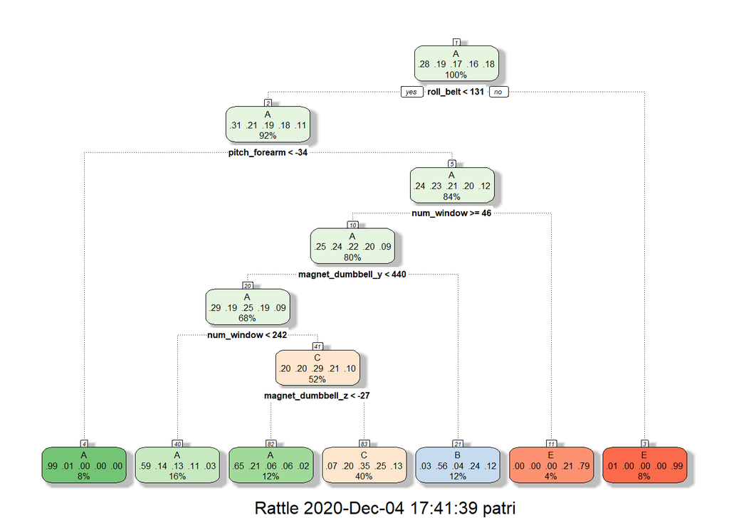

```r
modFitrp <- train(classe~.,method="rpart",data=training)
rattle::fancyRpartPlot(modFitrp$finalModel)
```

## Apply random forest model to testing dataset and display classe predictions.

```r
testpred <-predict(modFitrf, testing)
testpred
```

```
##  [1] B A B A A E D B A A B C B A E E A B B B
## Levels: A B C D E
```